# Equine Turnout at St. Lawrence University

Clara Mugnai

# Introduction

This project is an exploration of turnout preferences for horses both in the St. Lawrence University riding program, and boarding at the school’s barn. The facility all of the horses were located at and all of the data was gathered at is the Elsa Gunnison Appleton Riding Hall, in Canton, NY. The horses were turned out in rotations based on where they had previously done well outside. They were then observed in 30-minute intervals and various behaviors were recorded.

An article by Foster also identifies horse personalities, the same four types as Barteau. The main focus of Foster’s article is the way horses express discomfort with minimal movement. She identifies that the eyes and other facial indicators are the most informative signals and that changes in body posture and natural movement are other signals to how a horse feels in turnout (2019). She also discusses that certain horses have different baselines, and these behaviors are universally signals of discomfort.

I used Foster’s article heavily as a way to determine what I should take into account when observing horses. There were certain accommodations made for the fact that there was a single researcher doing all of the observations, accounting for the times of day and the scale for the number of tail swishes. The outside research completed by others, as well as personal experience, weighed into the way the numerical scales were done. There was more emphasis on if a horse was grazing or calmy moving around the space, than on how many times something alerted them. The overall way they behave in turnout better indicates the contentedness of the horse than small moments of spooking or alarm. This is a consistent school of thought, across both sources referenced here (Foster, Barteau).

# Methods

Site Map: Elsa Gunnison Appleton Riding Hall

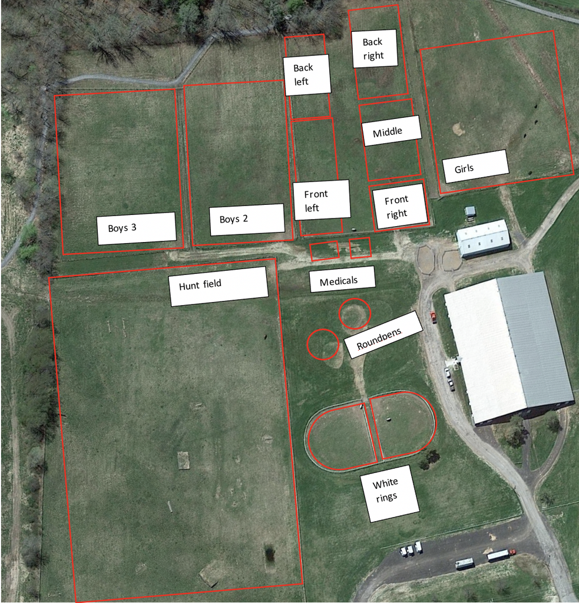

Image 1: layout of turnout spaces at St. Lawrence Universities, Elsa Gunnison Appleton Riding Hall

Horses were observed for 30-minute intervals in their natural turnout environments and groups. The intervals in which they were observed were randomized as much as possible, as well as the locations they were in. My personal class schedule and the weather dictated which days and times worked to observe in, and I attempted to rotate through the fields the same way the entire time I took observations. I started in the white rings and moved in a clockwise direction around the fields (white rings, round-pens, medicals, hunt field, boys 3, boys 2,etc). The horses take turns going out, at the discretion of the barn manager, and that is not a set schedule so the ones being observed changed each week.

It is important to note that the turnout location of a medical has no grass for them to graze on, only hay put there by humans, so those observations are outliers in that regard. During observation time it was noted how many minutes were spent both grazing (a positive behavior) and pacing (a negative behavior), while acknowledging that they could be doing neither of those things. In addition to that, the number of times they whinnied, dilated their nostrils, or had a rigid body posture were noted as negative signs in turnout. For horses both alone and with friends in turnout it was noted how many positive or negative social interactions they had with each other. Positive interactions were things like nuzzling or grooming and negative were running, chasing, or causing one another distress. Horses in solitary turnout could still be bothered or settled down by neighboring horses so they could have positive or negative interactions, as well. Finally, it was noted how often the horses were swishing their tails with the following scale:

- Frequent – almost constant – score 4 negative
- Often – regularly – score 2 negative
- Infrequent – some but not overly obvious – score 2 positive
- Rare – hardly ever – score 4 positive

Note: The scale used for finding these numbers was arbitrary, and chosen for the fact that it made sense given the importance of tail swishing compared to the overall turnout scores for each horse. The total number of tail swishes per horse, per observation session, were not possible to be observed so this scale was chosen instead.

Upon the completion of data collection overall turnout scores were calculated. This was done by adding; the minutes grazing, tail swishing score (if positive) , positive friend interactions, and minutes laying down together to be a positive score. Negative scores were; the sum of minutes pacing, tail swishing score (if negative), occurrences of body tension, whinnying, nostril dilation, and negative friend interactions (Foster). Choosing to add these numbers together was a subjective decision because every observation was 30 minutes long and all of the things that indicated a pleasant time for the horse were considered positive, all of the unpleasant things were considered negative (Paddock Anxiety). The positive and negative scores were then added together to give an overall turnout score.

For any horses that appeared 3 or more times in the data set, their observations were kept and are included in the final data set. Those horses were each then observed for approximately 10 minutes in the barn to quickly assess their personality types. In those 10 minutes they were exposed to new stimuli in the form of a human, another horse, and a foreign object to see how they reacted. Based on those reactions they were classified as either social, aloof, challenging, or fearful. For each type there was both a passive or aggressive form, depending on how fast or intense the reactions to the stimuli were (Barteau).

# Exploratory Analysis

```r
library(tidyverse)
library(ggplot2)
library(readxl)
library(dplyr)
library(lme4)
turnout_data <- read_excel("SYE data sheet.xlsx",
 col_types = c(
 ))
```

Using total negative signs instead of Overall because that is not as biased towards horses with turnout where there are grass.

```r
turnout_data %>% group_by(Horse) %>% summarise(mean(Totalnegativesigns))
```

```
## # A tibble: 18 × 2
##    Horse   `mean(Totalnegativesigns)`
##    <chr>                        <dbl>
##  1 Bling                        0.333
##  2 Cenvia                       0.333
##  3 Cheeto                       2.67
##  4 Cortez                       0
##  5 Epsom                        7
##  6 Henry                       21
##  7 Juno                         3
##  8 Kirk                         5
##  9 Logan                       17
## 10 Lucy                         0
## 11 Milo                        17
## 12 Monroe                       5
## 13 Mouse                        5.4
## 14 Obi                          9.33
## 15 Oscar                        5
## 16 Patches                     14
## 17 Tucker                       3
## 18 Vox                          5.75
```

```r
turnout_data %>% group_by(Personality) %>% summarise(mean(Totalnegativesigns))
```

```
## # A tibble: 7 × 2
##   Personality              `mean(Totalnegativesigns)`
##   <chr>                                         <dbl>
## 1 Aloof - Aggressive                             5
## 2 Aloof - Passive                                3.12
## 3 Challenging - Aggressive                       5.75
## 4 Challenging - Passive                          2.67
## 5 Fearful - Passive                             19
## 6 Social - Aggressive                            8.6
## 7 Social - Passive                               3.36
```

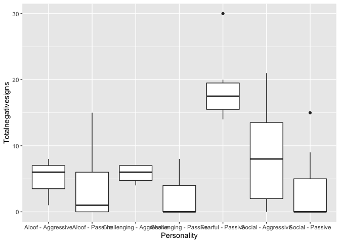

```r
ggplot(data = turnout_data, mapping = aes(x = Personality, y = Totalnegativesigns)) +
  geom_boxplot()
```

Interesting things happening but have to watch how many observations per group

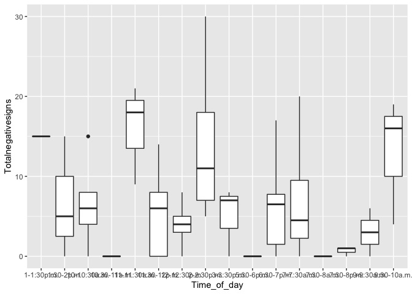

```r
ggplot(data = turnout_data, mapping = aes(x = Time_of_day, y = Totalnegativesigns)) + geom_boxplot()
```

This is really chaotic and hard to interpret, with no clear trends.

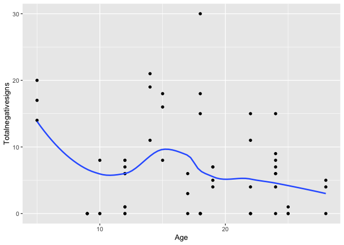

```r
ggplot(data = turnout_data, mapping = aes(x = Age, y = Totalnegativesigns)) + geom_point() + geom_smooth(se = FALSE)
```

A slight negative trend here but it is hard to interpret as there are very few observations on the left side of the plot.

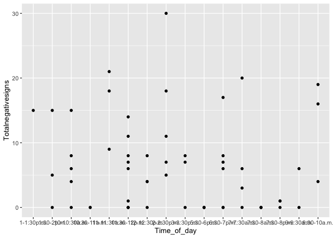

```r
ggplot(data = turnout_data, mapping = aes(x = Time_of_day, y = Totalnegativesigns)) + geom_point() + geom_smooth(se = FALSE)
```

Why am I not getting a smoother for this plot?

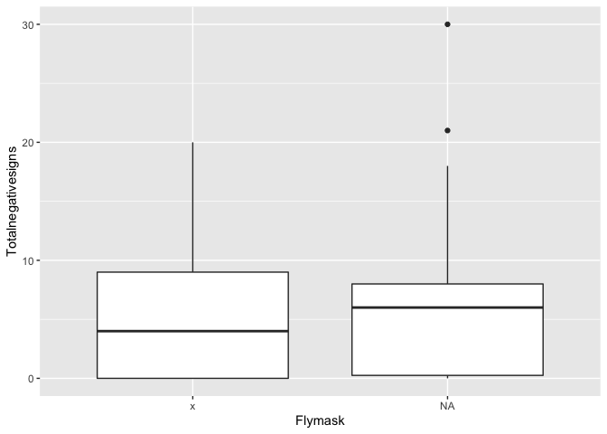

```r
ggplot(data = turnout_data, mapping = aes(x = Flymask, y = Totalnegativesigns)) + geom_boxplot()
```

This is interesting but the biggest takeaway from this plot is that there are two outliers in the “no flymask category”

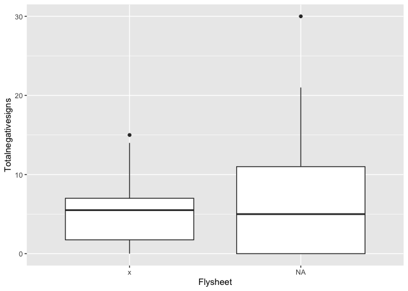

```r
ggplot(data = turnout_data, mapping = aes(x = Flysheet, y = Totalnegativesigns)) + geom_boxplot()
```

There is not a large difference here, again the outliers are the most significant things in this plot.

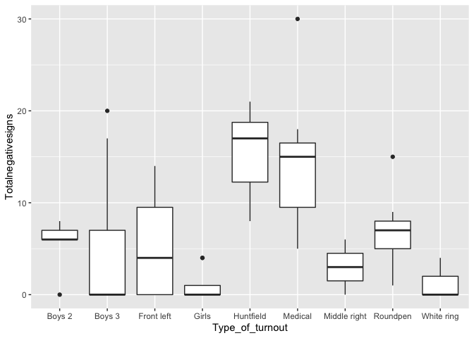

```r
ggplot(data = turnout_data, mapping = aes(x = Type_of_turnout, y = Totalnegativesigns)) + geom_boxplot()
```

It looks like certain fields have more success but it also needs to be considered which horses go in those fields.

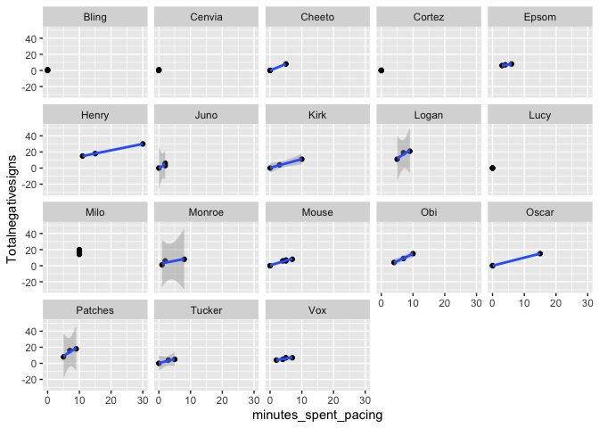

```r
ggplot(turnout_data, aes(x=minutes_spent_pacing,y=Totalnegativesigns)) +
  geom_point() +
  geom_smooth(method="lm") +
  facet_wrap("Horse")
```

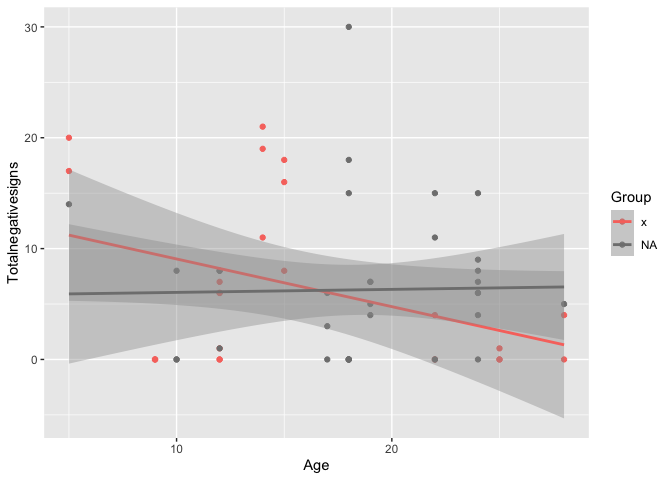

```r
ggplot(data=turnout_data,aes(x=Age,y=Totalnegativesigns,color=Group)) +
  geom_point() +
  geom_smooth(method="lm")
```

Exploring multilevel scenarios, it looks like Age and Group may be related, with different slopes for group and non-group, so as age increases in a group the group does better but as age increases in individual horses they do worse.

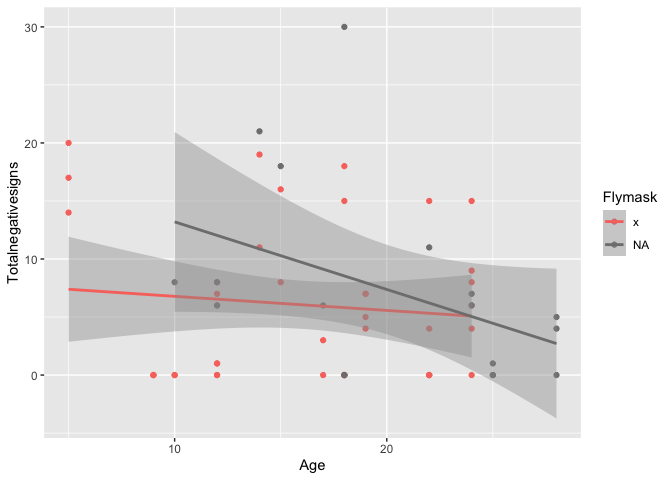

```r
ggplot(data=turnout_data,aes(x=Age,y=Totalnegativesigns,color=Flymask)) +
  geom_point() +
  geom_smooth(method="lm")
```

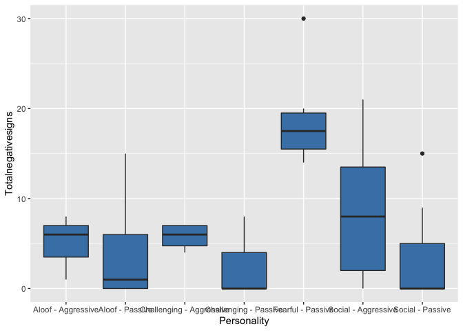

```r
ggplot(turnout_data, aes(x=Personality,y=Totalnegativesigns)) +
  geom_boxplot(fill="steelblue")
```

The different personalities definitely are different, and we have seen that each horse is different so we do need to account for the grouped horses. the personalities seem to make a difference in the slopes here but we have to be mindful of the fact that there are very few of each personalities.

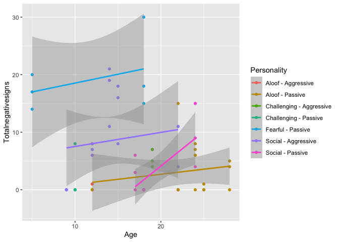

```r
ggplot(data=turnout_data,aes(x=Age,y=Totalnegativesigns,color=Personality)) +
  geom_point() +
  geom_smooth(method="lm")
```

Unconditional means model:

```r
unmeanmod = lmer(Totalnegativesigns ~ 1 + (1|Horse), data = turnout_data, REML = T)
summary(unmeanmod)
```

```
## Linear mixed model fit by REML ['lmerMod']
## Formula: Totalnegativesigns ~ 1 + (1 | Horse)
##    Data: turnout_data
##
## REML criterion at convergence: 366.8
##
## Scaled residuals:
##     Min      1Q  Median      3Q     Max
## -1.3529 -0.3494 -0.1392  0.3525  2.6805
##
## Random effects:
##  Groups   Name        Variance Std.Dev.
##  Horse    (Intercept) 35.79    5.983
##  Residual             16.58    4.072
## Number of obs: 59, groups:  Horse, 18
##
## Fixed effects:
##             Estimate Std. Error t value
## (Intercept)    6.685      1.509    4.43
```

Looking at the unconditional means model, the ICC value is (35.79/(16.58+35.79) = 0.68, so this is a multilevel data set and needs to be allowed to have different intercepts and “slopes” for different horses.

** Notes to self:

Figure out smoother - line 110

Clean up boxplots and all graphs

Put tables into pander so they are neater

# Citations

Barteau, Y. (2009, March 5). Understanding horse personalities, part 1: The 4 basic personality types. Dressage Today. Retrieved December 9, 2021, from https://dressagetoday.com/theory/horse-personalities-basic-types.

Chaya, L., Cowan, E., & McGuire, B. (2006). A note on the relationship between time spent in turnout and behavior during turnout in horses (Equus caballus). Applied Animal Behavior Science, 98(1-2), 155–160. https://doi.org/10.1016/j.applanim.2005.08.020

Foster, R. (2019, October 1). Recognizing pain in stoic horses. The Horse. Retrieved December 9, 2021, from https://thehorse.com/113343/recognizing-pain-in-stoic-horses/.

Paddock anxiety: How to help your horse relax. TRTmethod. (2020, October 12). Retrieved December 9, 2021, from https://www.trtmethod.com/separation-anxiety/how-to-deal- with-paddock-anxiety/.